Back to Article

###### Results

Download Source

# Results

Author

Kendra Wyant

Published

October 4, 2024

```
In [1]:
```

```r
options(knitr.kable.NA = '')
```

## Results

### Participant Characteristics

A total of 336 participants enrolled in our study and provided at least one month of data. [@tbl-demo] presents the demographic and clinical characteristics of these participants.

```
In [2]:
```

```
In [3]:
```

```python
table_dem |>
  knitr::kable(digits = 1)
```

Demographic and Clinical Characteristics

|  | N | % | M | SD | Range |
| --- | --- | --- | --- | --- | --- |
| Age |  |  |  |  |  |
| 18-21 | 2 | 0.6 |  |  |  |
| 22-25 | 8 | 2.4 |  |  |  |
| 26-35 | 124 | 37.0 |  |  |  |
| 36-45 | 118 | 35.2 |  |  |  |
| 46-55 | 64 | 19.1 |  |  |  |
| 56-65 | 14 | 4.2 |  |  |  |
| Over 65 | 4 | 1.2 |  |  |  |
| Gender |  |  |  |  |  |
| Man | 175 | 52.2 |  |  |  |
| Non-binary | 4 | 1.2 |  |  |  |
| Not listed above | 2 | 0.6 |  |  |  |
| Prefer not to say | 1 | 0.3 |  |  |  |
| Woman | 152 | 45.4 |  |  |  |
| Orientation |  |  |  |  |  |
| Bisexual | 44 | 13.1 |  |  |  |
| Lesbian or gay | 17 | 5.1 |  |  |  |
| Not listed above | 4 | 1.2 |  |  |  |
| Not sure | 1 | 0.3 |  |  |  |
| Straight, that is, not gay or lesbian | 268 | 80.0 |  |  |  |
| Race or Origin (Select all that apply) |  |  |  |  |  |
| American Indian or Alaska Native | 20 | 6.0 |  |  |  |
| Asian | 6 | 1.8 |  |  |  |
| Black or African American | 54 | 16.1 |  |  |  |
| Hispanic, Latino, or Spanish Origin | 30 | 9.0 |  |  |  |
| Native Hawaiian or Other Pacific Islander | 3 | 0.9 |  |  |  |
| Not Listed Above | 5 | 1.5 |  |  |  |
| White or Caucasian | 258 | 77.0 |  |  |  |
| Education |  |  |  |  |  |
| 8th grade or less | 7 | 2.1 |  |  |  |
| Some high school, but did not graduate | 28 | 8.4 |  |  |  |
| High school graduate or GED | 106 | 31.6 |  |  |  |
| Some college or 2-year degree | 145 | 43.3 |  |  |  |
| 4-year college graduate | 35 | 10.4 |  |  |  |
| More than 4-year or advanced degree | 13 | 3.9 |  |  |  |
| Employment |  |  |  |  |  |
| Disabled, not able to work | 39 | 11.6 |  |  |  |
| Employed, working 1-39 hours per week | 80 | 23.9 |  |  |  |
| Employed, working 40 or more hours per week | 60 | 17.9 |  |  |  |
| Not employed, NOT looking for work | 33 | 9.9 |  |  |  |
| Not employed, looking for work | 119 | 35.5 |  |  |  |
| Retired | 3 | 0.9 |  |  |  |
| Annual Household Income |  |  |  |  |  |
| Less than $25,000 | 187 | 55.8 |  |  |  |
| $25,000 - $34,999 | 46 | 13.7 |  |  |  |
| $35,000 - $49,999 | 40 | 11.9 |  |  |  |
| $50,000 - $74,999 | 36 | 10.7 |  |  |  |
| $75,000 - $99,999 | 14 | 4.2 |  |  |  |
| $100,000 - $149,999 | 6 | 1.8 |  |  |  |
| $150,000 - $199,999 | 4 | 1.2 |  |  |  |
| $200,000 or more | 1 | 0.3 |  |  |  |
| In a Committed Romantic Relationship |  |  |  |  |  |
| No | 147 | 43.9 |  |  |  |
| Yes | 187 | 55.8 |  |  |  |
| DSM-5 OUD Symptom Count |  |  | 9.9 | 2.2 | 0 - 11 |
| OUD Medication |  |  |  |  |  |
| I am not taking any medications for opioid use | 31 | 9.3 |  |  |  |
| Medication taken daily (e.g., Suboxone, Methadone) and medication taken monthly (e.g., Vivitrol) | 42 | 12.5 |  |  |  |
| Medications taken daily (e.g., Suboxone, Methadone) | 239 | 71.3 |  |  |  |
| Medications taken monthly (e.g., Vivitrol) | 23 | 6.9 |  |  |  |
| Reported 1 or More Lapse During Study Period |  |  |  |  |  |
| Yes | 151 | 45.1 |  |  |  |
| No | 184 | 54.9 |  |  |  |
| Number of reported lapses |  |  | 22.8 | 95.2 | 0 - 1087 |

### Adherence

#### Participation

A total of 336 participants enrolled in our study and provided at least one month of EMA data. @fig-1 shows participant attrition over 12 months.

```
In [4]:
```

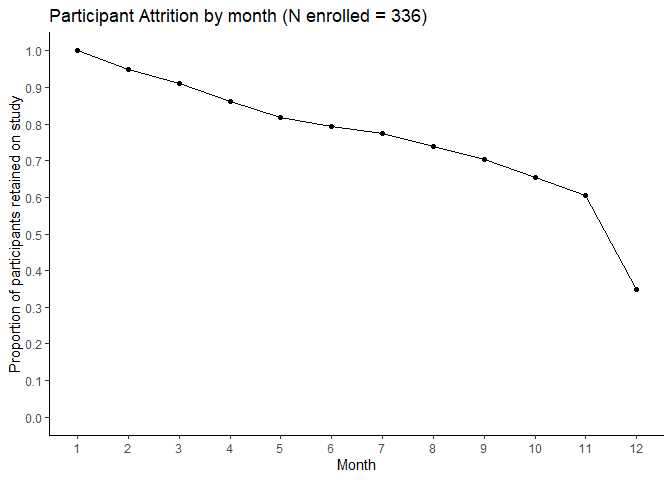

Study Attrition by Month

```python
disposition <- tibble(n = c(month_1, month_2, month_3, month_4, month_5, month_6,
                            month_7, month_8, month_9, month_10, month_11, month_12),
                      prop = n/month_1,
                      month = 1:12)


disposition |>
  group_by(month) |>
  ggplot(aes(x = month, y = prop)) +
  geom_point() +
  geom_line() +
  theme_classic() +
  scale_x_continuous(name = "Month",
                     breaks = seq(1, 12, 1)) +
  scale_y_continuous(name = "Proportion of participants retained on study",
                     breaks = seq(0, 1, .1),
                     limits = c(0, 1)) +
  labs(title = "Participant Attrition by month (N enrolled = 336)") +
  theme(legend.title = element_blank())
```

#### Daily and Monthly Updates

```
In [5]:
```

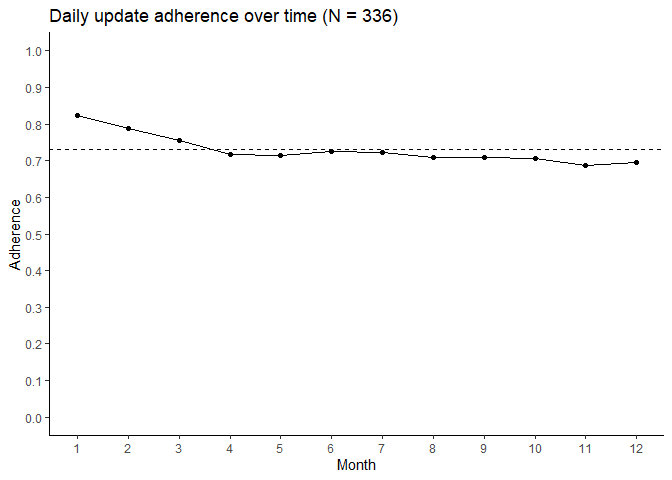

Daily Update Adherence by Month on Study

```python
ema_month_adherence |>
  group_by(month) |>
  summarize(mean_adherence = mean(adherence)) |>
  ggplot(aes(x = month, y = mean_adherence)) +
  geom_point() +
  geom_line() +
  theme_classic() +
  scale_x_continuous(name = "Month",
                     breaks = seq(1, 12, 1)) +
  scale_y_continuous(name = "Adherence",
                     breaks = seq(0, 1, .1),
                     limits = c(0, 1)) +
  labs(title = "Daily update adherence over time (N = 336) ") +
  theme(legend.title = element_blank()) +
  geom_hline(aes(yintercept = mean(mean_adherence)), linetype = "dashed", linewidth = .3)
```

### Participant Experience Questionannaire Quantitative Results

247 participants provided at least four months of data and completed the participant experience questionnaire. These participants were included in following analyses.

#### Interference

84% of participants (N = 207/247) disagreed (i.e., endorsing “Strongly disagree” or “Mildly disagree”) with the statement “Completing the daily update interfered with my daily activities”. 79% of participants (N = 196/247) disagreed with the statement “Completing the monthly update interfered with my daily activities”. We provide histograms of participant responses in the supplement.

An ICC (type 3) showed that, on average, interference ratings were moderately consistent across the two updates, ICC = .50, 95% CI = [.40 - .59].

#### Dislike

85% of participants (N = 211/247) disagreed with the statement “I disliked completing the daily update”. 73% of participants (N = 179/246) disagreed with the statement “I disliked completing the monthly update”. Fewer participants disagreed with the statement “I disliked [sensing method]” for geolocation (65%; N = 161/247), SMS and phone logs (64%; N = 158/246), and SMS content (64%; N = 156/245). As a result we saw an increase in responses endorsing a neutral stance toward these passive sensing methods (“Agree and disagree equally”). We provide histograms of participant responses by sensing method in the supplement.

An ICC (type 3) showed that, on average, dislike ratings were moderately consistent across sensing methods, ICC = .48, 95% CI = [.42 - .54].

### Participant Experience Questionannaire Qualitative Results